# GE 509 Preliminary Analysis

```r
summary(wcs_M_root.data) ## check mineral root data
```

```
##  Core_Master_ID  Elevation  Site         Plot     Litter_box
##  Min.   :  1.0   High:108   H1:36   Min.   :1   Min.   :4.00
##  1st Qu.: 54.8   Low :108   H2:36   1st Qu.:1   1st Qu.:4.00
##  Median :120.5              H3:36   Median :2   Median :4.00
##  Mean   :120.5              L1:36   Mean   :2   Mean   :4.33
##  3rd Qu.:186.2              L2:36   3rd Qu.:3   3rd Qu.:5.00
##  Max.   :240.0              L3:36   Max.   :3   Max.   :5.00
##
##  Rep_.A.or.B.          Core_Type    Elevation.1       Harvest
##  A:108        50um Exclusion:108   Min.   :375   July_2012:72
##  B:108        Ingrowth      :108   1st Qu.:401   Oct_2012 :72
##                                    Median :525   Oct_2013 :72
##                                    Mean   :496
##                                    3rd Qu.:555
##                                    Max.   :595
##
##     Harvest_Date   Soil_Type   Installation_Date Years_Since_Installed
##  15-Oct-12:72    Mineral:216   Min.   :40688     Min.   :1.12
##  41561    :72    Organic:  0   1st Qu.:40689     1st Qu.:1.12
##  8-Jul-12 :72                  Median :40690     Median :1.39
##                                Mean   :40689     Mean   :1.63
##                                3rd Qu.:40690     3rd Qu.:2.39
##                                Max.   :40690     Max.   :2.39
##
##  Coin_Envelope_Mass_g Coin_envelope_plus_Root_dry_mass_g Root_dry_mass_g
##  Min.   :3.62         Min.   :3.63                       Min.   :0.000
##  1st Qu.:3.68         1st Qu.:3.73                       1st Qu.:0.000
##  Median :3.73         Median :3.87                       Median :0.075
##  Mean   :3.77         Mean   :3.88                       Mean   :0.140
##  3rd Qu.:3.90         3rd Qu.:3.98                       3rd Qu.:0.240
##  Max.   :4.00         Max.   :4.66                       Max.   :0.920
##                       NA's   :13
##  Root_Production_g_yr.1 Mean_30_Day_VWC Mean_30_Day_Temperature
##  Min.   :0.0000         Min.   :0.247   Min.   :12.8
##  1st Qu.:0.0000         1st Qu.:0.284   1st Qu.:13.5
##  Median :0.0377         Median :0.312   Median :13.9
##  Mean   :0.0814         Mean   :0.318   Mean   :13.9
##  3rd Qu.:0.1428         3rd Qu.:0.332   3rd Qu.:14.4
##  Max.   :0.5255         Max.   :0.454   Max.   :14.6
##
```

[output cut: 9 more lines]

```
##  Min.   : 9.28               Min.   :-1.650
##  1st Qu.: 9.92               1st Qu.:-0.700
##  Median :11.99               Median :-0.150
##  Mean   :12.74               Mean   :-0.269
##  3rd Qu.:15.83               3rd Qu.: 0.100
##  Max.   :17.56               Max.   : 0.800
##
##  Maximum_Frost_Depth Cumulative_Frost_Depth Frost_Depth_auc Snow_Depth_AUC
##  Min.   : 0.00       Min.   : 0.00          Min.   :  0.0   Min.   : 724
##  1st Qu.: 0.00       1st Qu.: 0.00          1st Qu.:  0.0   1st Qu.:1306
##  Median : 1.00       Median : 1.50          Median : 19.7   Median :2331
##  Mean   : 2.72       Mean   : 7.87          Mean   : 99.8   Mean   :2222
##  3rd Qu.: 4.67       3rd Qu.:13.67          3rd Qu.:161.5   3rd Qu.:2480
##  Max.   :13.67       Max.   :36.00          Max.   :513.2   Max.   :4489
##
```

I want to present the root data in figures to answer whether root biomass is different in ingrowth versus exclusion cores and whether root production differs across the gradient as a function of winter snow or frost depth and duration

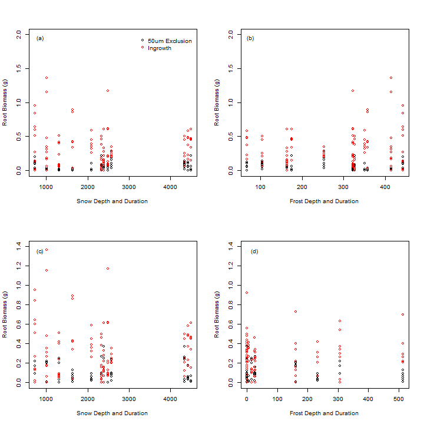

```r
par(mfrow=c(2,2))

## Make plot of root biomass in exclusion cores for organic soil horizon
plot(Root_dry_mass_g[which(Core_Type=="50um Exclusion")]~Snow_Depth_AUC[which(Core_Type=="50um Exclusion")],
   col=1,
   ylim=c(0,2),
   xlab="Snow Depth and Duration",
   ylab="Root Biomass (g)",
   data=wcs_OH_root.data)

## add points to figure that show root biomass in the ingrowth cores for organic soil
points(Root_dry_mass_g[which(Core_Type=="Ingrowth")]~Snow_Depth_AUC[which(Core_Type=="Ingrowth")], col=2, data=wcs_OH_root.data)

legend("topright", inset=0.03,
      c("50um Exclusion","Ingrowth"),
      bty="n",
      pch=c(1,1),
      col=c("1","2"))
      text(850,1.95,"(a)") ##add letter to distinguish panels

## plot of root biomass in the organic soil as a function of frost depth and duration

plot(Root_dry_mass_g[which(Core_Type=="50um Exclusion")]~Frost_Depth_auc[which(Core_Type=="50um Exclusion")],
   col=1,
   ylim=c(0,2),
   xlab="Frost Depth and Duration",
   ylab="Root Biomass (g)",
   data=wcs_OH_root.data)

## add points to figure that show root biomass in the ingrowth cores for organic soil
points(Root_dry_mass_g[which(Core_Type=="Ingrowth")]~Frost_Depth_auc[which(Core_Type=="Ingrowth")], col=2, data=wcs_OH_root.data)

text(75, 1.95,"(b)") ##add letter to distinguish panels

## Make plot of root biomass in exclusion cores for mineral soil horizon
plot(Root_dry_mass_g[which(Core_Type=="50um Exclusion")]~Snow_Depth_AUC[which(Core_Type=="50um Exclusion")], ylim=c(0,1.4),
   col=1,
   xlab="Snow Depth and Duration",
   ylab="Root Biomass (g)",
   data=wcs_M_root.data)

## add points to figure that show root biomass in the ingrowth cores for mineral soil soil
points(Root_dry_mass_g[which(Core_Type=="Ingrowth")]~Snow_Depth_AUC[which(Core_Type=="Ingrowth")], col=2, data=wcs_OH_root.data)

text(850,1.35,"(c)") ##panel C is root biomass by snow depth and duration in the mineral soil

## add scatterplot showing root biomass in the ingrowth cores as a function of frost
## depth and duration for mineral soil
plot(Root_dry_mass_g[which(Core_Type=="50um Exclusion")]~Frost_Depth_auc[which(Core_Type=="50um Exclusion")], ylim=c(0,1.4),
   col=1,
   xlab="Frost Depth and Duration",
   ylab="Root Biomass (g)",
   data=wcs_M_root.data)

## add points to figure that show root biomass in the ingrowth cores as a function of frost
## depth and duration for mineral soil
points(Root_dry_mass_g[which(Core_Type=="Ingrowth")]~Frost_Depth_auc[which(Core_Type=="Ingrowth")], col=2, data=wcs_M_root.data)

text(25,1.35,"(d)")
```

The figure above shows root biomass as a function of (a) snow depth and duration and (b) frost depth and duration in the organic soil (soil less than 5 cm below the surface) and © snow depth and duration and (d) frost depth and duration in the mineral soil (soil more than 5 cm below the surface).

Just looking at it - to me it looks there is an exponential relationship in the organic soil between root biomass and (a) snow or (b) frost depth.

I ultimately want to know whether root production is affected by the winter climate variables and so my next step will be to calculate root production as biomass produced divided by core incubation time * area of core. I will fit an exponential relationship to the data and hope to use mixed effect modeling to determine whether production differed over time.

*One thing I am stuck on and would love feedback from whoever reviews this is how to run generalized linear mixed model with this root biomass / production data in R.*

I am just confused on how to specify the error distribution and link function because the data is exponential

Rather than get bogged down - I went ahead and used regular mixed effect model to determine whether root biomass is affected by the fixed effect core type (ingrowth versus exclusion)

The random effects in this data set are sites, boxes, harvest dates, replicate cores.

```r
require(nlme)
root_biomass.lme1<-lme(Root_dry_mass_g ~ Core_Type*Soil_Type, random=(~1|Site), data=root.wcs[-207,]) ##excluding root biomass data from row 207

summary(root_biomass.lme1)
```

```
## Linear mixed-effects model fit by REML
##  Data: root.wcs[-207, ]
##      AIC    BIC logLik
##   -256.7 -232.4  134.4
##
## Random effects:
##  Formula: ~1 | Site
##         (Intercept) Residual
## StdDev:     0.01044   0.1726
##
## Fixed effects: Root_dry_mass_g ~ Core_Type * Soil_Type
##                                       Value Std.Error  DF t-value p-value
## (Intercept)                         0.06444   0.01714 422   3.759  0.0002
## Core_TypeIngrowth                   0.15028   0.02349 422   6.399  0.0000
## Soil_TypeOrganic                   -0.02116   0.02354 422  -0.899  0.3693
## Core_TypeIngrowth:Soil_TypeOrganic  0.10051   0.03325 422   3.023  0.0027
##  Correlation:
##                                    (Intr) Cr_TyI Sl_TyO
## Core_TypeIngrowth                  -0.685
## Soil_TypeOrganic                   -0.683  0.499
## Core_TypeIngrowth:Soil_TypeOrganic  0.484 -0.706 -0.708
##
## Standardized Within-Group Residuals:
##     Min      Q1     Med      Q3     Max
## -1.7411 -0.3882 -0.2086  0.3661  6.1651
##
## Number of Observations: 431
## Number of Groups: 6
```

Root biomass is greater in the ingrowth cores meaning the treatment worked. I would like to re-run this analysis however to account for the non-normal distribution of the data

## Objective 2 and 3 - N mineralization and Microbial Enzyme Data

Soil N cycling processes (nitrification and net N mineralization) were measured in short term lab incubations. I started out again making some exploratory histograms and boxplots to visualize the data.

```r
##load N mineralization data
WCS_Nmin.data<-read.csv(file="C:/Users/Patrick Sorensen/Documents/Winter Climate Gradient/Data/2012_2013_Winter Climate Study_N mineralization.csv", header=T)

str(WCS_Nmin.data) ## check that data are correctly coded as either continuous or categorical data
```

```
## 'data.frame':    436 obs. of  25 variables:
##  $ Core_Master_ID                 : int  1 2 3 4 5 6 7 8 9 10 ...
##  $ Elevation                      : Factor w/ 3 levels "","High","Low": 2 2 2 2 2 2 2 2 2 2 ...
##  $ Site_ID                        : Factor w/ 7 levels "","H1","H2","H3",..: 2 2 2 2 2 2 3 3 3 3 ...
##  $ Site_Elevation                 : int  539 539 539 539 539 539 555 555 555 555 ...
##  $ Plot                           : int  1 1 2 2 3 3 1 1 2 2 ...
##  $ Litter_box                     : int  4 4 4 4 4 4 4 4 4 4 ...
##  $ Rep_.A.or.B.                   : Factor w/ 3 levels "","A","B": 2 3 2 3 2 3 2 3 2 3 ...
##  $ Core_Type                      : Factor w/ 3 levels "","50um Exclusion",..: 3 3 3 3 3 3 3 3 3 3 ...
##  $ Harvest                        : Factor w/ 4 levels "","July_2012",..: 2 2 2 2 2 2 2 2 2 2 ...
##  $ Harvest_Date                   : Factor w/ 4 levels "","14-Oct-13",..: 4 4 4 4 4 4 4 4 4 4 ...
##  $ Soil_Type                      : Factor w/ 3 levels "","Mineral","Organic": 3 3 3 3 3 3 3 3 3 3 ...
##  $ Mean_30_Day_VWC                : num  0.37 0.37 0.37 0.37 0.37 0.37 0.45 0.45 0.45 0.45 ...
##  $ Mean_30_Day_Temperature        : num  12.9 12.9 12.9 12.9 12.9 ...
##  $ Mean_10_Day_VWC                : num  0.33 0.33 0.33 0.33 0.33 0.33 0.39 0.39 0.39 0.39 ...
##  $ Mean_10_Day_Temperature        : num  15.2 15.2 15.2 15.2 15.2 ...
##  $ Day_of_Sampling_Mean_VWC       : num  0.31 0.31 0.31 0.31 0.31 0.31 0.36 0.36 0.36 0.36 ...
##  $ Day_of_Sampling_Temperature    : num  15.8 15.8 15.8 15.8 15.8 ...
##  $ Minimum_Winter_Soil_Temperature: num  0.55 0.55 0.55 0.55 0.55 0.55 -0.15 -0.15 -0.15 -0.15 ...
##  $ Maximum_Frost_Depth            : num  3.33 3.33 3.33 3.33 3.33 3.33 5 5 5 5 ...
##  $ Cumulative_Frost_Depth         : num  12.3 12.3 12.3 12.3 12.3 ...
##  $ Frost_Depth_auc                : num  164 164 164 164 164 ...
##  $ Snow_Depth_AUC                 : num  2383 2383 2383 2383 2383 ...
##  $ Root_Dry_Biomass_g             : num  0.12 0.15 0.13 0.13 0.07 0 0.18 0.16 0.06 0 ...
##  $ Net_Nitrification              : num  0.67 0.723 0.737 0.678 0.425 0.808 0.497 0.48 0.541 0.597 ...
##  $ Net_Mineralization             : num  6.12 7.76 2.61 11.41 8.6 ...
```

```r
summary(WCS_Nmin.data) ## print summary statistics
```

```
##  Core_Master_ID  Elevation  Site_ID Site_Elevation      Plot
##  Min.   :  1.0       :  4     : 4   Min.   :375    Min.   :1
##  1st Qu.: 54.8   High:216   H1:72   1st Qu.:401    1st Qu.:1
##  Median :120.5   Low :216   H2:72   Median :525    Median :2
##  Mean   :120.5              H3:72   Mean   :496    Mean   :2
##  3rd Qu.:186.2              L1:72   3rd Qu.:555    3rd Qu.:3
##  Max.   :240.0              L2:72   Max.   :595    Max.   :3
##  NA's   :4                  L3:72   NA's   :4      NA's   :4
##    Litter_box   Rep_.A.or.B.          Core_Type        Harvest
##  Min.   :4.00    :  4                      :  4            :  4
##  1st Qu.:4.00   A:216        50um Exclusion:216   July_2012:144
##  Median :4.00   B:216        Ingrowth      :216   Oct_2012 :144
##  Mean   :4.33                                     Oct_2013 :144
##  3rd Qu.:5.00
##  Max.   :5.00
##  NA's   :4
##           Harvest_Date   Soil_Type   Mean_30_Day_VWC
##                 :  4          :  4   Min.   :0.250
##  14-Oct-13      :144   Mineral:216   1st Qu.:0.280
##  15-October-2012:144   Organic:216   Median :0.310
##  8-July-2012    :144                 Mean   :0.316
##                                      3rd Qu.:0.330
##                                      Max.   :0.450
##                                      NA's   :4
##  Mean_30_Day_Temperature Mean_10_Day_VWC Mean_10_Day_Temperature
##  Min.   :12.8            Min.   :0.240   Min.   : 9.65
##  1st Qu.:13.5            1st Qu.:0.280   1st Qu.:10.41
##  Median :13.9            Median :0.310   Median :12.17
##  Mean   :13.9            Mean   :0.318   Mean   :12.85
##  3rd Qu.:14.3            3rd Qu.:0.340   3rd Qu.:15.44
##  Max.   :14.6            Max.   :0.470   Max.   :17.05
##  NA's   :4               NA's   :4       NA's   :4
##  Day_of_Sampling_Mean_VWC Day_of_Sampling_Temperature
##  Min.   :0.240            Min.   : 9.28
##  1st Qu.:0.280            1st Qu.: 9.92
##  Median :0.305            Median :11.99
##  Mean   :0.311            Mean   :12.74
##  3rd Qu.:0.340            3rd Qu.:15.83
##  Max.   :0.470            Max.   :17.56
##  NA's   :4                NA's   :4
```

[output cut: 9 more lines]

```
##  Min.   : 0.00          Min.   :  0.0   Min.   : 724   Min.   :0.000
##  1st Qu.: 1.59          1st Qu.: 22.4   1st Qu.:1306   1st Qu.:0.000
##  Median :13.67          Median :169.3   Median :2331   Median :0.080
##  Mean   :14.62          Mean   :191.3   Mean   :2222   Mean   :0.161
##  3rd Qu.:25.12          3rd Qu.:323.0   3rd Qu.:2480   3rd Qu.:0.240
##  Max.   :36.00          Max.   :513.2   Max.   :4489   Max.   :2.860
##  NA's   :4              NA's   :4       NA's   :4      NA's   :4
##  Net_Nitrification Net_Mineralization
##  Min.   :-1.791    Min.   :-4.01
##  1st Qu.: 0.318    1st Qu.: 0.90
##  Median : 0.572    Median : 2.61
##  Mean   : 0.794    Mean   : 6.48
##  3rd Qu.: 1.003    3rd Qu.: 7.68
##  Max.   : 6.526    Max.   :68.15
##  NA's   :7         NA's   :7
```

```r
WCS_Nmin.data<-na.omit(WCS_Nmin.data) ##remove NAs data from data set
summary(WCS_Nmin.data) ##print summary
```

```
##  Core_Master_ID Elevation  Site_ID Site_Elevation      Plot
##  Min.   :  1        :  0     : 0   Min.   :375    Min.   :1.00
##  1st Qu.: 54    High:213   H1:71   1st Qu.:401    1st Qu.:1.00
##  Median :121    Low :216   H2:72   Median :511    Median :2.00
##  Mean   :121               H3:70   Mean   :495    Mean   :1.99
##  3rd Qu.:187               L1:72   3rd Qu.:555    3rd Qu.:3.00
##  Max.   :240               L2:72   Max.   :595    Max.   :3.00
##                            L3:72
##    Litter_box   Rep_.A.or.B.          Core_Type        Harvest
##  Min.   :4.00    :  0                      :  0            :  0
##  1st Qu.:4.00   A:214        50um Exclusion:215   July_2012:144
##  Median :4.00   B:215        Ingrowth      :214   Oct_2012 :141
##  Mean   :4.33                                     Oct_2013 :144
##  3rd Qu.:5.00
##  Max.   :5.00
##
##           Harvest_Date   Soil_Type   Mean_30_Day_VWC
##                 :  0          :  0   Min.   :0.250
##  14-Oct-13      :144   Mineral:214   1st Qu.:0.280
##  15-October-2012:141   Organic:215   Median :0.310
##  8-July-2012    :144                 Mean   :0.316
##                                      3rd Qu.:0.330
##                                      Max.   :0.450
##
##  Mean_30_Day_Temperature Mean_10_Day_VWC Mean_10_Day_Temperature
##  Min.   :12.8            Min.   :0.240   Min.   : 9.65
##  1st Qu.:13.5            1st Qu.:0.280   1st Qu.:10.41
##  Median :13.9            Median :0.310   Median :12.18
##  Mean   :13.9            Mean   :0.318   Mean   :12.87
##  3rd Qu.:14.3            3rd Qu.:0.340   3rd Qu.:15.44
##  Max.   :14.6            Max.   :0.470   Max.   :17.05
##
##  Day_of_Sampling_Mean_VWC Day_of_Sampling_Temperature
##  Min.   :0.24             Min.   : 9.28
##  1st Qu.:0.28             1st Qu.: 9.92
##  Median :0.30             Median :12.02
##  Mean   :0.31             Mean   :12.76
##  3rd Qu.:0.34             3rd Qu.:15.83
##  Max.   :0.47             Max.   :17.56
##
```

[output cut: 9 more lines]

```
##  Min.   : 0.00          Min.   :  0.0   Min.   : 724   Min.   :0.00
##  1st Qu.: 1.67          1st Qu.: 25.1   1st Qu.:1306   1st Qu.:0.00
##  Median :13.67          Median :174.7   Median :2331   Median :0.07
##  Mean   :14.69          Mean   :192.2   Mean   :2220   Mean   :0.16
##  3rd Qu.:25.50          3rd Qu.:325.9   3rd Qu.:2480   3rd Qu.:0.24
##  Max.   :36.00          Max.   :513.2   Max.   :4489   Max.   :2.86
##
##  Net_Nitrification Net_Mineralization
##  Min.   :-1.791    Min.   :-4.01
##  1st Qu.: 0.318    1st Qu.: 0.90
##  Median : 0.572    Median : 2.61
##  Mean   : 0.794    Mean   : 6.48
##  3rd Qu.: 1.003    3rd Qu.: 7.68
##  Max.   : 6.526    Max.   :68.15
##
```

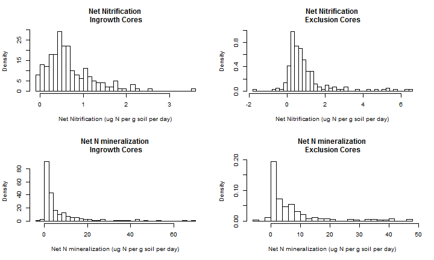

```r
par(mfrow=c(2,2))

## starting with net Nitrification in Ingrowth cores
hist(WCS_Nmin.data$Net_Nitrification[which(WCS_Nmin.data$Core_Type=="Ingrowth")],
     breaks=30,
     main = "Net Nitrification\n Ingrowth Cores",
     xlab = "Net Nitrification (ug N per g soil per day)",
     ylab = "Density")

## then net Nitrification in Exclusion cores
hist(WCS_Nmin.data$Net_Nitrification[which(WCS_Nmin.data$Core_Type=="50um Exclusion")],
     breaks=30, freq=FALSE,
     main = "Net Nitrification\n Exclusion Cores",
     xlab = "Net Nitrification (ug N per g soil per day)",
     ylab = "Density")

## and net mineralization in Ingrowth cores
hist(WCS_Nmin.data$Net_Mineralization[which(WCS_Nmin.data$Core_Type=="Ingrowth")],
     breaks=30,
     main = "Net N mineralization\n Ingrowth Cores",
     xlab = "Net N mineralization (ug N per g soil per day)",
     ylab = "Density")

## and net mineralization in exclusion cores
hist(WCS_Nmin.data$Net_Mineralization[which(WCS_Nmin.data$Core_Type=="50um Exclusion")],
     breaks=30, freq=FALSE,
     main = "Net N mineralization\n Exclusion Cores",
     xlab = "Net N mineralization (ug N per g soil per day)",
     ylab = "Density")
```

The histograms show that the N mineralization data has some positive skew to it

As with the root biomass data I made some boxplots of either nitrification or N mineralization separated by ingrowth core type, soil horizon, and harvest date.

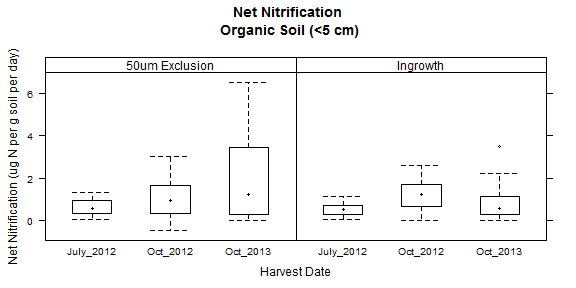

```r
require(lattice)
bwplot(Net_Nitrification~Harvest|Core_Type, data=WCS_Nmin.data,
    strip = strip.custom(bg = 'white'),
    subset = Soil_Type!="Mineral",
    cex = .5, layout = c(2, 1),
    main = "Net Nitrification\n Organic Soil (<5 cm)",
    xlab = "Harvest Date", ylab = "Net Nitrification (ug N per g soil per day)",
    par.settings = list(
    box.rectangle = list(col = 1),
    box.umbrella  = list(col = 1),
    plot.symbol   = list(cex = .5, col = 1)),
     scales = list(x = list(relation = "same"),
                     y = list(relation = "same")))
```

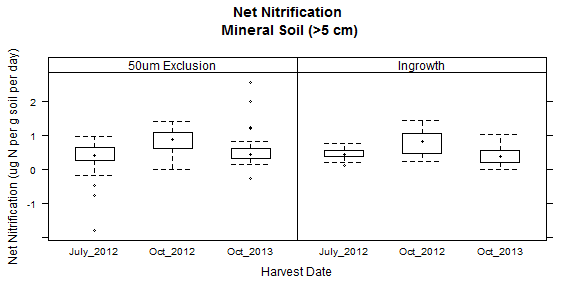

```r
## and nitrification in mineral soils by harvest date
bwplot(Net_Nitrification~Harvest|Core_Type, data=WCS_Nmin.data,
    strip = strip.custom(bg = 'white'),
    subset = Soil_Type!="Organic",
    cex = .5, layout = c(2, 1),
    main = "Net Nitrification\n Mineral Soil (>5 cm)",
    xlab = "Harvest Date", ylab = "Net Nitrification (ug N per g soil per day)",
    par.settings = list(
    box.rectangle = list(col = 1),
    box.umbrella  = list(col = 1),
    plot.symbol   = list(cex = .5, col = 1)),
     scales = list(x = list(relation = "same"),
                     y = list(relation = "same")))
```

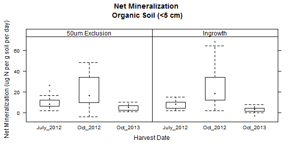

```r
## now make boxplot showing net N mineralization in organic soils by harvest date
bwplot(Net_Mineralization~Harvest|Core_Type, data=WCS_Nmin.data,
    strip = strip.custom(bg = 'white'),
    subset = Soil_Type!="Mineral",
    cex = .5, layout = c(2, 1),
    main = "Net Mineralization\n Organic Soil (<5 cm)",
    xlab = "Harvest Date", ylab = "Net Mineralization (ug N per g soil per day)",
    par.settings = list(
    box.rectangle = list(col = 1),
    box.umbrella  = list(col = 1),
    plot.symbol   = list(cex = .5, col = 1)),
     scales = list(x = list(relation = "same"),
                     y = list(relation = "same")))
```

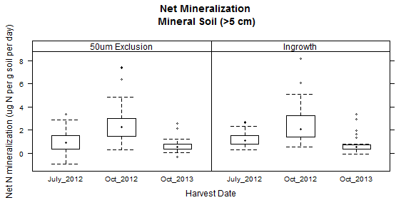

```r
## and net N mineralization in mineral soil by harvest date
bwplot(Net_Mineralization~Harvest|Core_Type, data=WCS_Nmin.data,
    strip = strip.custom(bg = 'white'),
    subset = Soil_Type!="Organic",
    cex = .5, layout = c(2, 1),
    main = "Net Mineralization\n Mineral Soil (>5 cm)",
    xlab = "Harvest Date", ylab = "Net N mineralization (ug N per g soil per day)",
    par.settings = list(
    box.rectangle = list(col = 1),
    box.umbrella  = list(col = 1),
    plot.symbol   = list(cex = .5, col = 1)),
     scales = list(x = list(relation = "same"),
                     y = list(relation = "same")))
```

The boxplots suggest that at any given sampling time there is not a difference in N cycling between the two core types

The analysis I want to do is to examine the different fixed effects and see how they were related to microbial N cycling. Core Type (root ingrowth versus exclusion) is the fixed effect that most directly addresses the main research question of whether winter climate effects on microbes are direct or are mediated by plant roots.

Again, I am little unsure of how to account for the non-normal distribution in the data and have begun by doing some analyses using just mixed effects models

I ran linear mixed effects models to determine whether (1) net nitrification or net N mineralization are affected by (1) core type (2) harvest date (3) interactions among core type and winter climate (either frost, snow, or minimum winter soil temperature)

The first set of models is for nitrification in the organic soil horizon

```r
##subset the data before beginning to run analyses on soil horizons separately
WCS_Nmin_OH.data<-subset(WCS_Nmin.data, Soil_Type=="Organic", select=Core_Master_ID:Net_Mineralization)
WCS_Nmin_M.data<-subset(WCS_Nmin.data, Soil_Type=="Mineral", select=Core_Master_ID:Net_Mineralization)

Net_Nitrification_OH.lme1<-summary(lme(Net_Nitrification~Core_Type, random=(~1|Site_ID), data=WCS_Nmin_OH.data)) ##core type

Net_Nitrification_OH.lme2<-summary(lme(Net_Nitrification~Harvest, random=(~1|Site_ID),data=WCS_Nmin_OH.data)) ##harvest date

Net_Nitrification_OH.lme3<-summary(lme(Net_Nitrification~Core_Type*Frost_Depth_auc, random=(~1|Site_ID),data=WCS_Nmin_OH.data)) ##Frost Depth AUC

Net_Nitrification_OH.lme4<-summary(lme(Net_Nitrification~Core_Type*Minimum_Winter_Soil_Temperature, random=(~1|Site_ID),data=WCS_Nmin_OH.data)) ##minimum soil temperature

Net_Nitrification_OH.lme5<-summary(lme(Net_Nitrification~Core_Type*Snow_Depth_AUC, random=(~1|Site_ID),data=WCS_Nmin_OH.data)) ##snow depth auc

Net_Nitrification_OH.lme1 ##core type
```

```
## Linear mixed-effects model fit by REML
##  Data: WCS_Nmin_OH.data
##     AIC   BIC logLik
##   629.9 643.3 -310.9
##
## Random effects:
##  Formula: ~1 | Site_ID
##         (Intercept) Residual
## StdDev:      0.5962    0.988
##
## Fixed effects: Net_Nitrification ~ Core_Type
##                     Value Std.Error  DF t-value p-value
## (Intercept)        1.2607    0.2615 208   4.822   0.000
## Core_TypeIngrowth -0.4501    0.1348 208  -3.340   0.001
##  Correlation:
##                   (Intr)
## Core_TypeIngrowth -0.259
##
## Standardized Within-Group Residuals:
##     Min      Q1     Med      Q3     Max
## -2.2289 -0.5510 -0.1768  0.1755  4.9569
##
## Number of Observations: 215
## Number of Groups: 6
```

There is a significant effect of type on nitrification in the organic soil (<5cm), where nitrification is lower in ingrowth compared to exclusion cores

```r
Net_Nitrification_OH.lme2 ##harvest date
```

```
## Linear mixed-effects model fit by REML
##  Data: WCS_Nmin_OH.data
##     AIC BIC logLik
##   615.2 632 -302.6
##
## Random effects:
##  Formula: ~1 | Site_ID
##         (Intercept) Residual
## StdDev:      0.5972   0.9476
##
## Fixed effects: Net_Nitrification ~ Harvest
##                  Value Std.Error  DF t-value p-value
## (Intercept)     0.5575    0.2682 207   2.079  0.0388
## HarvestOct_2012 0.5615    0.1585 207   3.543  0.0005
## HarvestOct_2013 0.8708    0.1579 207   5.514  0.0000
##  Correlation:
##                 (Intr) HO_2012
## HarvestOct_2012 -0.293
## HarvestOct_2013 -0.294  0.498
##
## Standardized Within-Group Residuals:
##     Min      Q1     Med      Q3     Max
## -2.1781 -0.5561 -0.1526  0.3068  4.9883
##
## Number of Observations: 215
## Number of Groups: 6
```

```r
Net_Nitrification_OH.lme3 ##frost depth auc
```

```
## Linear mixed-effects model fit by REML
##  Data: WCS_Nmin_OH.data
##     AIC   BIC logLik
##   600.3 620.4 -294.1
##
## Random effects:
##  Formula: ~1 | Site_ID
##         (Intercept) Residual
## StdDev:       0.283   0.8779
##
## Fixed effects: Net_Nitrification ~ Core_Type * Frost_Depth_auc
##                                    Value Std.Error  DF t-value p-value
## (Intercept)                        3.655    0.3180 206  11.492       0
## Core_TypeIngrowth                 -1.874    0.3242 206  -5.782       0
## Frost_Depth_auc                   -0.008    0.0010 206  -8.436       0
## Core_TypeIngrowth:Frost_Depth_auc  0.005    0.0011 206   4.731       0
##  Correlation:
##                                   (Intr) Cr_TyI Frs_D_
## Core_TypeIngrowth                 -0.511
## Frost_Depth_auc                   -0.893  0.493
## Core_TypeIngrowth:Frost_Depth_auc  0.475 -0.929 -0.530
##
## Standardized Within-Group Residuals:
##     Min      Q1     Med      Q3     Max
## -2.5907 -0.5284 -0.1145  0.3817  4.0801
##
## Number of Observations: 215
## Number of Groups: 6
```

frost depth is significantly related to nitrification in organic soil and interacts with core type

```r
Net_Nitrification_OH.lme4 ##minimum soil temperature
```

```
## Linear mixed-effects model fit by REML
##  Data: WCS_Nmin_OH.data
##     AIC BIC logLik
##   624.9 645 -306.4
##
## Random effects:
##  Formula: ~1 | Site_ID
##         (Intercept) Residual
## StdDev:      0.2702   0.9808
##
## Fixed effects: Net_Nitrification ~ Core_Type * Minimum_Winter_Soil_Temperature
##                                                     Value Std.Error  DF
## (Intercept)                                        1.5114    0.1567 206
## Core_TypeIngrowth                                 -0.5495    0.1468 206
## Minimum_Winter_Soil_Temperature                    0.9253    0.2138 206
## Core_TypeIngrowth:Minimum_Winter_Soil_Temperature -0.3641    0.2211 206
##                                                   t-value p-value
## (Intercept)                                         9.645  0.0000
## Core_TypeIngrowth                                  -3.743  0.0002
## Minimum_Winter_Soil_Temperature                     4.327  0.0000
## Core_TypeIngrowth:Minimum_Winter_Soil_Temperature  -1.647  0.1011
##  Correlation:
##                                                   (Intr) Cr_TyI M_W_S_
## Core_TypeIngrowth                                 -0.472
## Minimum_Winter_Soil_Temperature                    0.372 -0.215
## Core_TypeIngrowth:Minimum_Winter_Soil_Temperature -0.196  0.412 -0.519
##
## Standardized Within-Group Residuals:
##     Min      Q1     Med      Q3     Max
## -2.2869 -0.4860 -0.1785  0.2358  4.9877
##
## Number of Observations: 215
## Number of Groups: 6
```

minimum soil temperature is a significant factor, but does not interact with core type

```r
Net_Nitrification_OH.lme5 ##snow depth and duration
```

```
## Linear mixed-effects model fit by REML
##  Data: WCS_Nmin_OH.data
##     AIC BIC logLik
##   584.9 605 -286.5
##
## Random effects:
##  Formula: ~1 | Site_ID
##         (Intercept) Residual
## StdDev:      0.1721   0.8332
##
## Fixed effects: Net_Nitrification ~ Core_Type * Snow_Depth_AUC
##                                    Value Std.Error  DF t-value p-value
## (Intercept)                      -0.6311   0.20272 206  -3.113  0.0021
## Core_TypeIngrowth                 0.9837   0.24473 206   4.020  0.0001
## Snow_Depth_AUC                    0.0008   0.00008 206  10.971  0.0000
## Core_TypeIngrowth:Snow_Depth_AUC -0.0006   0.00010 206  -6.598  0.0000
##  Correlation:
##                                  (Intr) Cr_TyI S_D_AU
## Core_TypeIngrowth                -0.604
## Snow_Depth_AUC                   -0.850  0.558
## Core_TypeIngrowth:Snow_Depth_AUC  0.534 -0.886 -0.630
##
## Standardized Within-Group Residuals:
##     Min      Q1     Med      Q3     Max
## -2.4213 -0.5939 -0.2088  0.4468  4.1726
##
## Number of Observations: 215
## Number of Groups: 6
```

snow depth and duration is significantly related to nitrification in organic soil and interacts with core type

The data show that there are interesting effects of the presence or absence of roots on nitrification in the organic which interacts with winter climate.

I did a similar analysis for N mineralization in the organic soil

```r
Net_Mineralization_OH.lme1<-summary(lme(Net_Mineralization~Core_Type, random=~1|Site_ID,data=WCS_Nmin_OH.data, method="ML")) ##core type

Net_Mineralization_OH.lme2<-summary(lme(Net_Mineralization~Harvest, random=(~1|Site_ID),data=WCS_Nmin_OH.data)) ##harvest date

Net_Mineralization_OH.lme3<-summary(lme(Net_Mineralization~Core_Type*Frost_Depth_auc, random=(~1|Site_ID),data=WCS_Nmin_OH.data)) ##Frost Depth AUC

Net_Mineralization_OH.lme4<-summary(lme(Net_Mineralization~Core_Type*Minimum_Winter_Soil_Temperature, random=(~1|Site_ID),data=WCS_Nmin_OH.data)) ##minimum soil temperature

Net_Mineralization_OH.lme5<-summary(lme(Net_Mineralization~Core_Type*Snow_Depth_AUC, random=(~1|Site_ID),data=WCS_Nmin_OH.data)) ##snow depth auc

Net_Mineralization_OH.lme1 ##core type
```

```
## Linear mixed-effects model fit by maximum likelihood
##  Data: WCS_Nmin_OH.data
##    AIC  BIC logLik
##   1673 1687 -832.7
##
## Random effects:
##  Formula: ~1 | Site_ID
##         (Intercept) Residual
## StdDev:       4.233    11.35
##
## Fixed effects: Net_Mineralization ~ Core_Type
##                    Value Std.Error  DF t-value p-value
## (Intercept)       11.655     2.057 208   5.667  0.0000
## Core_TypeIngrowth -0.341     1.555 208  -0.219  0.8266
##  Correlation:
##                   (Intr)
## Core_TypeIngrowth -0.38
##
## Standardized Within-Group Residuals:
##     Min      Q1     Med      Q3     Max
## -1.8346 -0.6053 -0.2730  0.2248  4.6128
##
## Number of Observations: 215
## Number of Groups: 6
```

There is not a significant effect of core type on net N mineralization in the organic soil (<5cm)

```r
Net_Mineralization_OH.lme2 ##harvest date
```

```
## Linear mixed-effects model fit by REML
##  Data: WCS_Nmin_OH.data
##    AIC  BIC logLik
##   1526 1543   -758
##
## Random effects:
##  Formula: ~1 | Site_ID
##         (Intercept) Residual
## StdDev:       4.902    8.128
##
## Fixed effects: Net_Mineralization ~ Harvest
##                  Value Std.Error  DF t-value p-value
## (Intercept)      8.495     2.219 207   3.829   2e-04
## HarvestOct_2012 13.826     1.359 207  10.170   0e+00
## HarvestOct_2013 -4.706     1.355 207  -3.474   6e-04
##  Correlation:
##                 (Intr) HO_2012
## HarvestOct_2012 -0.304
## HarvestOct_2013 -0.305  0.498
##
## Standardized Within-Group Residuals:
##      Min       Q1      Med       Q3      Max
## -3.94041 -0.47812 -0.08305  0.35004  5.05062
##
## Number of Observations: 215
## Number of Groups: 6
```

However, there is significant temporal effects on net N mineralization where net N mineralization was greatest in cores harvested in Oct 2012 and lowest in cores sampled in Oct 2013

```r
Net_Mineralization_OH.lme3 ##frost depth auc
```

```
## Linear mixed-effects model fit by REML
##  Data: WCS_Nmin_OH.data
##    AIC  BIC logLik
##   1665 1685 -826.4
##
## Random effects:
##  Formula: ~1 | Site_ID
##         (Intercept) Residual
## StdDev:       10.38     10.7
##
## Fixed effects: Net_Mineralization ~ Core_Type * Frost_Depth_auc
##                                    Value Std.Error  DF t-value p-value
## (Intercept)                       -8.035     5.986 206  -1.342  0.1809
## Core_TypeIngrowth                  2.472     3.950 206   0.626  0.5321
## Frost_Depth_auc                    0.070     0.014 206   4.805  0.0000
## Core_TypeIngrowth:Frost_Depth_auc -0.010     0.013 206  -0.771  0.4414
##  Correlation:
##                                   (Intr) Cr_TyI Frs_D_
## Core_TypeIngrowth                 -0.329
## Frost_Depth_auc                   -0.685  0.412
## Core_TypeIngrowth:Frost_Depth_auc  0.306 -0.929 -0.444
##
## Standardized Within-Group Residuals:
##     Min      Q1     Med      Q3     Max
## -2.0863 -0.6108 -0.2826  0.2994  4.6601
##
## Number of Observations: 215
## Number of Groups: 6
```

```r
Net_Mineralization_OH.lme4 ##minimum soil temperature
```

```
## Linear mixed-effects model fit by REML
##  Data: WCS_Nmin_OH.data
##    AIC  BIC logLik
##   1652 1672 -820.1
##
## Random effects:
##  Formula: ~1 | Site_ID
##         (Intercept) Residual
## StdDev:       5.233    11.08
##
## Fixed effects: Net_Mineralization ~ Core_Type * Minimum_Winter_Soil_Temperature
##                                                    Value Std.Error  DF
## (Intercept)                                       13.742     2.516 206
## Core_TypeIngrowth                                  0.248     1.659 206
## Minimum_Winter_Soil_Temperature                    7.773     2.897 206
## Core_TypeIngrowth:Minimum_Winter_Soil_Temperature  2.160     2.499 206
##                                                   t-value p-value
## (Intercept)                                         5.462  0.0000
## Core_TypeIngrowth                                   0.149  0.8815
## Minimum_Winter_Soil_Temperature                     2.683  0.0079
## Core_TypeIngrowth:Minimum_Winter_Soil_Temperature   0.864  0.3883
##  Correlation:
##                                                   (Intr) Cr_TyI M_W_S_
## Core_TypeIngrowth                                 -0.332
## Minimum_Winter_Soil_Temperature                    0.312 -0.178
## Core_TypeIngrowth:Minimum_Winter_Soil_Temperature -0.138  0.412 -0.432
##
## Standardized Within-Group Residuals:
##     Min      Q1     Med      Q3     Max
## -1.9055 -0.6102 -0.2295  0.2463  4.6278
##
## Number of Observations: 215
## Number of Groups: 6
```

minimum soil temperature is positively correlated with net N mineralization in the organic soil, no core type x min. winter soil temperature interaction

```r
Net_Mineralization_OH.lme5 ##snow depth and duration
```

```
## Linear mixed-effects model fit by REML
##  Data: WCS_Nmin_OH.data
##    AIC  BIC logLik
##   1648 1668   -818
##
## Random effects:
##  Formula: ~1 | Site_ID
##         (Intercept) Residual
## StdDev:       9.435    10.05
##
## Fixed effects: Net_Mineralization ~ Core_Type * Snow_Depth_AUC
##                                   Value Std.Error  DF t-value p-value
## (Intercept)                      27.027     4.616 206   5.855  0.0000
## Core_TypeIngrowth                -1.699     2.952 206  -0.576  0.5654
## Snow_Depth_AUC                   -0.007     0.001 206  -6.535  0.0000
## Core_TypeIngrowth:Snow_Depth_AUC  0.001     0.001 206   0.504  0.6151
##  Correlation:
##                                  (Intr) Cr_TyI S_D_AU
## Core_TypeIngrowth                -0.321
## Snow_Depth_AUC                   -0.509  0.495
## Core_TypeIngrowth:Snow_Depth_AUC  0.283 -0.886 -0.557
##
## Standardized Within-Group Residuals:
##     Min      Q1     Med      Q3     Max
## -2.5713 -0.5555 -0.2334  0.2816  4.7578
##
## Number of Observations: 215
## Number of Groups: 6
```

snow depth and duration is significantly negatively related to net N Mineralization in organic soil, but this effect is not different across cores types

Some scatterplots to illustrate the relationships between microbial N cycling processes and winter climate variables frost depth and duration, minimum winter soil temperature, and snow depth and duration

```r
Harvest_Core<-interaction(WCS_Nmin_OH.data$Harvest,WCS_Nmin_OH.data$Core_Type) ##made dummy variable for plotting

par(mfrow=c(2,3))

plot(Net_Mineralization[which(Harvest_Core=="July_2012.Ingrowth")]~Frost_Depth_auc[which(Harvest_Core=="July_2012.Ingrowth")], data=WCS_Nmin_OH.data,
     pch=19, col=1,
     ylim=c(0,60), xlim=c(0,500),
     ylab="Net N mineralization (ug N per g soil per day)",
     xlab="Frost Depth and Duration")

points(Net_Mineralization[which(Harvest_Core=="July_2012.50um Exclusion")]~Frost_Depth_auc[which(Harvest_Core=="July_2012.50um Exclusion")], col=1, data=WCS_Nmin_OH.data)

points(Net_Mineralization[which(Harvest_Core=="Oct_2012.Ingrowth")]~Frost_Depth_auc[which(Harvest_Core=="Oct_2012.Ingrowth")], data=WCS_Nmin_OH.data, pch=19, col="green")

points(Net_Mineralization[which(Harvest_Core=="Oct_2012.50um Exclusion")]~Frost_Depth_auc[which(Harvest_Core=="Oct_2012.50um Exclusion")], col="green", data=WCS_Nmin_OH.data)

points(Net_Mineralization[which(Harvest_Core=="Oct_2013.Ingrowth")]~Frost_Depth_auc[which(Harvest_Core=="Oct_2013.Ingrowth")], data=WCS_Nmin_OH.data, pch=19, col="blue")

points(Net_Mineralization[which(Harvest_Core=="Oct_2013.50um Exclusion")]~Frost_Depth_auc[which(Harvest_Core=="Oct_2013.50um Exclusion")], col="blue", data=WCS_Nmin_OH.data)

text(10,58, "(a)")

plot(Net_Mineralization[which(Harvest_Core=="July_2012.Ingrowth")]~Minimum_Winter_Soil_Temperature[which(Harvest_Core=="July_2012.Ingrowth")], data=WCS_Nmin_OH.data,
     pch=19, col=1,
     ylim=c(0,60), xlim=c(-2,2),
     ylab="Net N mineralization (ug N per g soil per day)",
     xlab="Minimum Soil Temperature")

points(Net_Mineralization[which(Harvest_Core=="July_2012.50um Exclusion")]~Minimum_Winter_Soil_Temperature[which(Harvest_Core=="July_2012.50um Exclusion")], col=1, data=WCS_Nmin_OH.data)

points(Net_Mineralization[which(Harvest_Core=="Oct_2012.Ingrowth")]~Minimum_Winter_Soil_Temperature[which(Harvest_Core=="Oct_2012.Ingrowth")], data=WCS_Nmin_OH.data, pch=19, col="green", ylim=c(-2,8))

points(Net_Mineralization[which(Harvest_Core=="Oct_2012.50um Exclusion")]~Minimum_Winter_Soil_Temperature[which(Harvest_Core=="Oct_2012.50um Exclusion")], col="green", data=WCS_Nmin_OH.data)

points(Net_Mineralization[which(Harvest_Core=="Oct_2013.Ingrowth")]~Minimum_Winter_Soil_Temperature[which(Harvest_Core=="Oct_2013.Ingrowth")], data=WCS_Nmin_OH.data, pch=19, col="blue", ylim=c(-2,8))

points(Net_Mineralization[which(Harvest_Core=="Oct_2013.50um Exclusion")]~Minimum_Winter_Soil_Temperature[which(Harvest_Core=="Oct_2013.50um Exclusion")], col="blue", data=WCS_Nmin_OH.data)

text(-1.9,58, "(b)")

plot(Net_Mineralization[which(Harvest_Core=="July_2012.Ingrowth")]~Snow_Depth_AUC[which(Harvest_Core=="July_2012.Ingrowth")], data=WCS_Nmin_OH.data,
     pch=19, col=1,
     ylim=c(0,60), xlim=c(200,5000),
     ylab="Net N mineralization (ug N per g soil per day)",
     xlab="Snow Depth and Duration")

points(Net_Mineralization[which(Harvest_Core=="July_2012.50um Exclusion")]~Snow_Depth_AUC[which(Harvest_Core=="July_2012.50um Exclusion")], col=1, data=WCS_Nmin_OH.data)

points(Net_Mineralization[which(Harvest_Core=="Oct_2012.Ingrowth")]~Snow_Depth_AUC[which(Harvest_Core=="Oct_2012.Ingrowth")], data=WCS_Nmin_OH.data, pch=19, col="green", ylim=c(-2,8))

points(Net_Mineralization[which(Harvest_Core=="Oct_2012.50um Exclusion")]~Snow_Depth_AUC[which(Harvest_Core=="Oct_2012.50um Exclusion")], col="green", data=WCS_Nmin_OH.data)

points(Net_Mineralization[which(Harvest_Core=="Oct_2013.Ingrowth")]~Snow_Depth_AUC[which(Harvest_Core=="Oct_2013.Ingrowth")], data=WCS_Nmin_OH.data, pch=19, col="blue", ylim=c(-2,8))

points(Net_Mineralization[which(Harvest_Core=="Oct_2013.50um Exclusion")]~Snow_Depth_AUC[which(Harvest_Core=="Oct_2013.50um Exclusion")], col="blue", data=WCS_Nmin_OH.data)

legend("topright", inset=0.0005,
      c("July 2012","October 2012","October 2013"),
      bty="n",
      pch=c(1,1,1),
      col=c("black","green","blue"), trace=TRUE)
```

```
##   xchar= 204.1 ; (yextra,ychar)= 0 3.373
##   points2( 3496 3496 3496 , 58.99 55.62 52.25 , pch= 1 1 1 , ...)
```

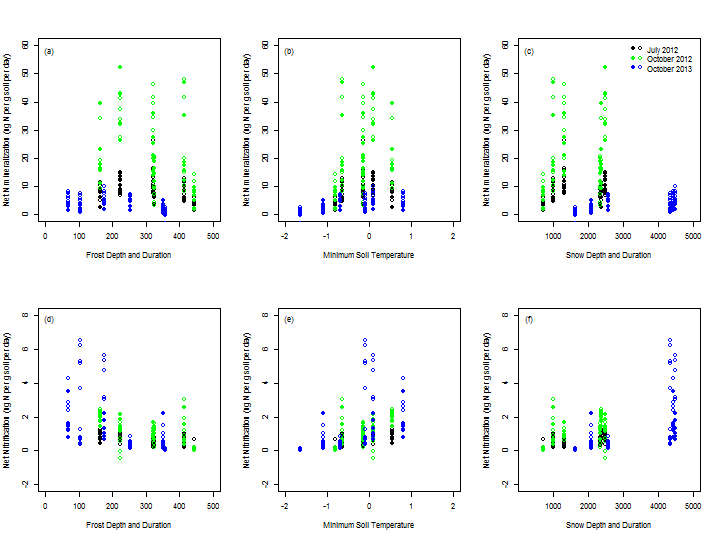

```r
points(3300,58.99, pch=19, col="black")
points(3300,55.62, pch=19, col="green")
points(3300,52.25, pch=19, col="blue")
text(300,58, "(c)")

plot(Net_Nitrification[which(Harvest_Core=="July_2012.Ingrowth")]~Frost_Depth_auc[which(Harvest_Core=="July_2012.Ingrowth")], data=WCS_Nmin_OH.data,
     pch=19, col=1,
     ylim=c(-2,8), xlim=c(0,500),
     ylab="Net Nitrification (ug N per g soil per day)",
     xlab="Frost Depth and Duration")

points(Net_Nitrification[which(Harvest_Core=="July_2012.50um Exclusion")]~Frost_Depth_auc[which(Harvest_Core=="July_2012.50um Exclusion")], col=1, data=WCS_Nmin_OH.data)

points(Net_Nitrification[which(Harvest_Core=="Oct_2012.Ingrowth")]~Frost_Depth_auc[which(Harvest_Core=="Oct_2012.Ingrowth")], data=WCS_Nmin_OH.data, pch=19, col="green", ylim=c(-2,8))

points(Net_Nitrification[which(Harvest_Core=="Oct_2012.50um Exclusion")]~Frost_Depth_auc[which(Harvest_Core=="Oct_2012.50um Exclusion")], col="green", data=WCS_Nmin_OH.data)

points(Net_Nitrification[which(Harvest_Core=="Oct_2013.Ingrowth")]~Frost_Depth_auc[which(Harvest_Core=="Oct_2013.Ingrowth")], data=WCS_Nmin_OH.data, pch=19, col="blue", ylim=c(-2,8))

points(Net_Nitrification[which(Harvest_Core=="Oct_2013.50um Exclusion")]~Frost_Depth_auc[which(Harvest_Core=="Oct_2013.50um Exclusion")], col="blue", data=WCS_Nmin_OH.data)

text(10,7.8,"(d)")

plot(Net_Nitrification[which(Harvest_Core=="July_2012.Ingrowth")]~Minimum_Winter_Soil_Temperature[which(Harvest_Core=="July_2012.Ingrowth")], data=WCS_Nmin_OH.data,
     pch=19, col=1,
     ylim=c(-2,8), xlim=c(-2,2),
     ylab="Net Nitrification (ug N per g soil per day)",
     xlab="Minimum Soil Temperature")

points(Net_Nitrification[which(Harvest_Core=="July_2012.50um Exclusion")]~Minimum_Winter_Soil_Temperature[which(Harvest_Core=="July_2012.50um Exclusion")], col=1, data=WCS_Nmin_OH.data)

points(Net_Nitrification[which(Harvest_Core=="Oct_2012.Ingrowth")]~Minimum_Winter_Soil_Temperature[which(Harvest_Core=="Oct_2012.Ingrowth")], data=WCS_Nmin_OH.data, pch=19, col="green", ylim=c(-2,8))

points(Net_Nitrification[which(Harvest_Core=="Oct_2012.50um Exclusion")]~Minimum_Winter_Soil_Temperature[which(Harvest_Core=="Oct_2012.50um Exclusion")], col="green", data=WCS_Nmin_OH.data)

points(Net_Nitrification[which(Harvest_Core=="Oct_2013.Ingrowth")]~Minimum_Winter_Soil_Temperature[which(Harvest_Core=="Oct_2013.Ingrowth")], data=WCS_Nmin_OH.data, pch=19, col="blue", ylim=c(-2,8))

points(Net_Nitrification[which(Harvest_Core=="Oct_2013.50um Exclusion")]~Minimum_Winter_Soil_Temperature[which(Harvest_Core=="Oct_2013.50um Exclusion")], col="blue", data=WCS_Nmin_OH.data)

text(-1.9,7.8,"(e)")

plot(Net_Nitrification[which(Harvest_Core=="July_2012.Ingrowth")]~Snow_Depth_AUC[which(Harvest_Core=="July_2012.Ingrowth")], data=WCS_Nmin_OH.data,
     pch=19, col=1,
     ylim=c(-2,8), xlim=c(200,5000),
     ylab="Net Nitrification (ug N per g soil per day)",
     xlab="Snow Depth and Duration")

points(Net_Nitrification[which(Harvest_Core=="July_2012.50um Exclusion")]~Snow_Depth_AUC[which(Harvest_Core=="July_2012.50um Exclusion")], col=1, data=WCS_Nmin_OH.data)

points(Net_Nitrification[which(Harvest_Core=="Oct_2012.Ingrowth")]~Snow_Depth_AUC[which(Harvest_Core=="Oct_2012.Ingrowth")], data=WCS_Nmin_OH.data, pch=19, col="green", ylim=c(-2,8))

points(Net_Nitrification[which(Harvest_Core=="Oct_2012.50um Exclusion")]~Snow_Depth_AUC[which(Harvest_Core=="Oct_2012.50um Exclusion")], col="green", data=WCS_Nmin_OH.data)

points(Net_Nitrification[which(Harvest_Core=="Oct_2013.Ingrowth")]~Snow_Depth_AUC[which(Harvest_Core=="Oct_2013.Ingrowth")], data=WCS_Nmin_OH.data, pch=19, col="blue", ylim=c(-2,8))

points(Net_Nitrification[which(Harvest_Core=="Oct_2013.50um Exclusion")]~Snow_Depth_AUC[which(Harvest_Core=="Oct_2013.50um Exclusion")], col="blue", data=WCS_Nmin_OH.data)

text(300, 7.8, "(f)")
```

In the figure above net N mineralization is shown as a function of (a) frost depth and duration (b) minimum winter soil temperature © and snow depth and duration. The bottom panels show nitrification as a function of (d) frost depth and duration (e) minimum winter soil temperature (f) and snow depth and duration.

The filled symbols are N cycling rates in the ingrowth cores and the hollow symbols are N cycling rates in the exclusion cores.

One challenge of this data set is apparent from the figure above, which is that most of the covariates measured along the gradient are highly correlated. For example, snow depth and duration and minimum winter soil temperature are both positively correlated with each other…and with nitrification in the organic soil horizon(panels e and f ).

I want to do model selection in order to determine the most parsimonious model of microbial activity and deal with the correlation among soil climate covariates along the gradient.

Again, I ran the analysis using linear mixed effects models to start off with, but hope to figure out how to account for the non-normal distribution of the data and re-analyze using a generalized linear mixed effects model

First, I set up a bunch of candidate models. I used the R package 'AICcmodavg' to tabulate information criteria to determine the most parsimonious model

```r
require(AICcmodavg) ##load AICcmodavg package
Nitr_OH_mod.1<-lme(Net_Nitrification ~ Core_Type, random= (~1|Site_ID), data=WCS_Nmin_OH.data, method="ML") ## core type only model

Nitr_OH_mod.2<-lme(Net_Nitrification ~ Core_Type + Frost_Depth_auc, random= (~1|Site_ID), data=WCS_Nmin_OH.data, method="ML") ## core type and frost depth and duration

Nitr_OH_mod.3<-lme(Net_Nitrification ~ Core_Type + Minimum_Winter_Soil_Temperature, random= (~1|Site_ID), data=WCS_Nmin_OH.data, method="ML") ## Core type and minimum winter soil temperature

Nitr_OH_mod.4<-lme(Net_Nitrification ~ Core_Type + Snow_Depth_AUC, random= (~1|Site_ID), data=WCS_Nmin_OH.data, method="ML") ## core type + Snow depth and duration

Nitr_OH_mod.5<-lme(Net_Nitrification ~ Core_Type + Day_of_Sampling_Temperature, random= (~1|Site_ID), data=WCS_Nmin_OH.data, method="ML") ## core type + soil temperature

Nitr_OH_mod.6<-lme(Net_Nitrification ~ Core_Type + Day_of_Sampling_Mean_VWC, random= (~1|Site_ID), data=WCS_Nmin_OH.data, method="ML") ## core type mean VWC

Nitr_OH_mod.7<-lme(Net_Nitrification ~ Frost_Depth_auc, random= (~1|Site_ID), data=WCS_Nmin_OH.data, method="ML") ## core type and frost depth and duration

Nitr_OH_mod.8<-lme(Net_Nitrification ~ Minimum_Winter_Soil_Temperature, random= (~1|Site_ID), data=WCS_Nmin_OH.data, method="ML") ## Core type and minimum winter soil temperature

Nitr_OH_mod.9<-lme(Net_Nitrification ~ Snow_Depth_AUC, random= (~1|Site_ID), data=WCS_Nmin_OH.data, method="ML") ## core type + Snow depth and duration

Nitr_OH_mod.10<-lme(Net_Nitrification ~ Day_of_Sampling_Temperature, random= (~1|Site_ID), data=WCS_Nmin_OH.data, method="ML") ## core type + soil temperature

Nitr_OH_mod.11<-lme(Net_Nitrification ~ Day_of_Sampling_Mean_VWC, random= (~1|Site_ID), data=WCS_Nmin_OH.data, method="ML") ## core type mean VWC

Nitr_OH_mod.12<-lme(Net_Nitrification ~ 1, random= (~1|Site_ID), data=WCS_Nmin_OH.data, method="ML")

Nitr_OH.Cand.models<-list(Nitr_OH_mod.1,Nitr_OH_mod.2,Nitr_OH_mod.3,Nitr_OH_mod.4,Nitr_OH_mod.5,Nitr_OH_mod.6,Nitr_OH_mod.7,Nitr_OH_mod.8,Nitr_OH_mod.9,Nitr_OH_mod.10,Nitr_OH_mod.11,Nitr_OH_mod.12)

Nitr_OH.Modnames<-c("Core Type","Core Type + Frost", "Core Type + Min. Winter Soil Temp","Core Type + Snow","Core Type + Vol Water Content","Core Type + Soil Temperature", "Frost", "Min. Winter Soil Temp", "Snow","Soil Temperature","Vol Water Content", "random intercept")

###print summary output
Nitr_OH_MOD.table<-aictab(cand.set=Nitr_OH.Cand.models, modnames=Nitr_OH.Modnames, second.ord=TRUE)

Nitr_OH_MOD.table
```

```
##
## Model selection based on AICc :
##
##                                   K  AICc Delta_AICc AICcWt Cum.Wt     LL
## Core Type + Snow                  5 583.3       0.00   0.97   0.97 -286.5
## Core Type + Frost                 5 591.0       7.77   0.02   0.99 -290.4
## Snow                              4 593.7      10.39   0.01   1.00 -292.7
## Frost                             4 601.4      18.15   0.00   1.00 -296.6
## Core Type + Vol Water Content     5 611.7      28.41   0.00   1.00 -300.7
## Core Type + Min. Winter Soil Temp 5 618.4      35.10   0.00   1.00 -304.0
## Soil Temperature                  4 621.5      38.23   0.00   1.00 -306.6
## Core Type + Soil Temperature      5 626.6      43.34   0.00   1.00 -308.2
## Core Type                         4 626.9      43.61   0.00   1.00 -309.4
## Min. Winter Soil Temp             4 627.3      44.00   0.00   1.00 -309.5
## Vol Water Content                 4 635.5      52.28   0.00   1.00 -313.7
## random intercept                  3 635.7      52.45   0.00   1.00 -314.8
```

The model selection suggests that the most parsimonious model of nitrification in the organic soil horizon includes core type and snow depth and duration - this implies that the effect of more or less snow along the gradient on microbial nitrification is in part mediated by the presence or absence of plant roots.

Model selection of N mineralization in the organic soil horizon

```r
Nmin_OH_mod.1<-lme(Net_Mineralization ~ Core_Type, random= (~1|Site_ID), data=WCS_Nmin_OH.data, method="ML") ## core type only model

Nmin_OH_mod.2<-lme(Net_Mineralization ~ Core_Type + Frost_Depth_auc, random= (~1|Site_ID), data=WCS_Nmin_OH.data, method="ML") ## core type and frost depth and duration

Nmin_OH_mod.3<-lme(Net_Mineralization ~ Core_Type + Minimum_Winter_Soil_Temperature, random= (~1|Site_ID), data=WCS_Nmin_OH.data, method="ML") ## Core type and minimum winter soil temperature

Nmin_OH_mod.4<-lme(Net_Mineralization ~ Core_Type + Snow_Depth_AUC, random= (~1|Site_ID), data=WCS_Nmin_OH.data, method="ML") ## core type + Snow depth and duration

Nmin_OH_mod.5<-lme(Net_Mineralization ~ Core_Type + Day_of_Sampling_Temperature, random= (~1|Site_ID), data=WCS_Nmin_OH.data, method="ML") ## core type + soil temperature

Nmin_OH_mod.6<-lme(Net_Mineralization ~ Core_Type + Day_of_Sampling_Mean_VWC, random= (~1|Site_ID), data=WCS_Nmin_OH.data, method="ML") ## core type mean VWC

Nmin_OH_mod.7<-lme(Net_Mineralization ~ Frost_Depth_auc, random= (~1|Site_ID), data=WCS_Nmin_OH.data, method="ML") ## core type and frost depth and duration

Nmin_OH_mod.8<-lme(Net_Mineralization ~ Minimum_Winter_Soil_Temperature, random= (~1|Site_ID), data=WCS_Nmin_OH.data, method="ML") ## Core type and minimum winter soil temperature

Nmin_OH_mod.9<-lme(Net_Mineralization ~ Snow_Depth_AUC, random= (~1|Site_ID), data=WCS_Nmin_OH.data, method="ML") ## core type + Snow depth and duration

Nmin_OH_mod.10<-lme(Net_Mineralization ~ Day_of_Sampling_Temperature, random= (~1|Site_ID), data=WCS_Nmin_OH.data, method="ML") ## core type + soil temperature

Nmin_OH_mod.11<-lme(Net_Mineralization ~ Day_of_Sampling_Mean_VWC, random= (~1|Site_ID), data=WCS_Nmin_OH.data, method="ML") ## core type mean VWC

Nmin_OH_mod.12<-lme(Net_Mineralization ~ 1, random= (~1|Site_ID), data=WCS_Nmin_OH.data, method="ML")

Nmin_OH.Cand.models<-list(Nmin_OH_mod.1,Nmin_OH_mod.2,Nmin_OH_mod.3,Nmin_OH_mod.4,Nmin_OH_mod.5,Nmin_OH_mod.6,Nmin_OH_mod.7,Nmin_OH_mod.8,Nmin_OH_mod.9,Nmin_OH_mod.10,Nmin_OH_mod.11,Nmin_OH_mod.12)

Nmin_OH.Modnames<-c("Core Type","Core Type + Frost", "Core Type + Min. Winter Soil Temp","Core Type + Snow","Core Type + Vol Water Content","Core Type + Soil Temperature", "Frost", "Min. Winter Soil Temp", "Snow","Soil Temperature","Vol Water Content", "random intercept")

###print summary output
Nmin_OH_MOD.table<-aictab(cand.set=Nmin_OH.Cand.models, modnames=Nmin_OH.Modnames, second.ord=TRUE)

Nmin_OH_MOD.table
```

```
##
## Model selection based on AICc :
##
##                                   K AICc Delta_AICc AICcWt Cum.Wt     LL
## Vol Water Content                 4 1618       0.00   0.73   0.73 -804.7
## Core Type + Soil Temperature      5 1620       2.00   0.27   0.99 -804.6
## Snow                              4 1628      10.05   0.00   1.00 -809.7
## Core Type + Snow                  5 1630      12.07   0.00   1.00 -809.7
## Soil Temperature                  4 1636      18.87   0.00   1.00 -814.1
## Core Type + Vol Water Content     5 1638      20.89   0.00   1.00 -814.1
## Frost                             4 1655      37.60   0.00   1.00 -823.5
## Core Type + Frost                 5 1657      39.63   0.00   1.00 -823.5
## Min. Winter Soil Temp             4 1662      44.83   0.00   1.00 -827.1
## Core Type + Min. Winter Soil Temp 5 1664      46.88   0.00   1.00 -827.1
## random intercept                  3 1672      53.94   0.00   1.00 -832.7
## Core Type                         4 1674      55.96   0.00   1.00 -832.7
```

Lastly, I just want illustrate the distribution of the microbial enzyme data that I am working with. We measured 6 microbial extracellular enzymes on two of the harvest dates (July 2012, October 2012,…still collecting Oct 2013 data). Each enzyme breaks down a specific component of soil organic matter

```r
WCS_enzyme.data<-read.csv(file="C:/Users/Patrick Sorensen/Documents/Winter Climate Gradient/Data/2012_2013_Winter_Climate_Gradient_Enzymes.csv", header=T) ##loading enzyme data

WCS_enzyme.data<-WCS_enzyme.data[-289,]
str(WCS_enzyme.data)
```

```
## 'data.frame':    288 obs. of  33 variables:
##  $ Core_Master_ID                 : int  1 2 3 4 5 6 7 8 9 10 ...
##  $ Site                           : Factor w/ 2 levels "High","Low": 1 1 1 1 1 1 1 1 1 1 ...
##  $ Site_ID                        : Factor w/ 6 levels "H1","H2","H3",..: 1 1 1 1 1 1 2 2 2 2 ...
##  $ Site_Elevation                 : int  539 539 539 539 539 539 555 555 555 555 ...
##  $ Plot                           : int  1 1 2 2 3 3 1 1 2 2 ...
##  $ Litter..box                    : int  4 4 4 4 4 4 4 4 4 4 ...
##  $ Rep.........A.or.B.            : Factor w/ 2 levels "A","B": 1 2 1 2 1 2 1 2 1 2 ...
##  $ Core_Type                      : Factor w/ 2 levels "50um Exclusion",..: 2 2 2 2 2 2 2 2 2 2 ...
##  $ Soil_Type                      : Factor w/ 2 levels "Mineral","Organic": 2 2 2 2 2 2 2 2 2 2 ...
##  $ Harvest                        : Factor w/ 2 levels "July_2012","Oct_2012": 1 1 1 1 1 1 1 1 1 1 ...
##  $ Tin.Weight..g.                 : num  0.97 1.04 1 1.01 1.05 1.05 1.01 1 1.01 1.01 ...
##  $ Tin...Wet.Soil.Org.Hor...g.    : num  4.45 5.37 4.46 4.83 5.38 7.43 5.45 5.22 8.11 5.55 ...
##  $ Wet.Soil..g.                   : num  3.48 4.33 3.46 3.82 4.33 6.38 4.44 4.22 7.1 4.54 ...
##  $ Tin...Dry.Soil..g.             : num  2.06 2.56 1.99 2 2.31 2.79 2.65 2.49 4.04 2.36 ...
```

[output cut: 19 more lines]

```r
summary(WCS_enzyme.data)
```

```
##  Core_Master_ID    Site     Site_ID Site_Elevation      Plot
##  Min.   :  1.0   High:144   H1:48   Min.   :375    Min.   :1
##  1st Qu.: 36.8   Low :144   H2:48   1st Qu.:401    1st Qu.:1
##  Median : 78.5              H3:48   Median :525    Median :2
##  Mean   : 78.5              L1:48   Mean   :496    Mean   :2
##  3rd Qu.:120.2              L2:48   3rd Qu.:555    3rd Qu.:3
##  Max.   :156.0              L3:48   Max.   :595    Max.   :3
##
##   Litter..box  Rep.........A.or.B.          Core_Type     Soil_Type
##  Min.   :4.0   A:144               50um Exclusion:144   Mineral:144
##  1st Qu.:4.0   B:144               Ingrowth      :144   Organic:144
##  Median :4.5
##  Mean   :4.5
##  3rd Qu.:5.0
##  Max.   :5.0
##
##       Harvest    Tin.Weight..g. Tin...Wet.Soil.Org.Hor...g.
##  July_2012:144   Min.   :0.90   Min.   : 3.15
##  Oct_2012 :144   1st Qu.:0.99   1st Qu.: 5.30
##                  Median :1.01   Median : 6.17
##                  Mean   :1.01   Mean   : 6.34
##                  3rd Qu.:1.02   3rd Qu.: 6.90
##                  Max.   :1.10   Max.   :15.05
##
##   Wet.Soil..g.   Tin...Dry.Soil..g.  Dry.Soil..g.  acid_phosphatase
##  Min.   : 2.05   Min.   :1.50       Min.   :0.40   Min.   : 0.00
##  1st Qu.: 4.32   1st Qu.:2.23       1st Qu.:1.24   1st Qu.: 2.34
##  Median : 5.15   Median :2.92       Median :1.92   Median : 4.30
##  Mean   : 5.33   Mean   :3.15       Mean   :2.14   Mean   : 5.02
##  3rd Qu.: 5.91   3rd Qu.:3.79       3rd Qu.:2.79   3rd Qu.: 7.33
##  Max.   :13.99   Max.   :8.83       Max.   :7.77   Max.   :21.95
##                                                    NA's   :3
##       NAG        beta_glucosidase cellobiohydrolase phenol_oxidase
##  Min.   :0.050   Min.   :0.010    Min.   :0.010     Min.   :0.030
##  1st Qu.:0.180   1st Qu.:0.410    1st Qu.:0.145     1st Qu.:0.362
##  Median :0.460   Median :0.560    Median :0.610     Median :0.595
##  Mean   :0.659   Mean   :0.861    Mean   :0.666     Mean   :0.828
##  3rd Qu.:0.910   3rd Qu.:0.960    3rd Qu.:1.065     3rd Qu.:1.058
##  Max.   :3.230   Max.   :7.500    Max.   :3.050     Max.   :5.150
##  NA's   :1       NA's   :3        NA's   :1         NA's   :10
```

[output cut: 25 more lines]

```
##  Min.   :0.00        Min.   : 0.00          Min.   :  0.0   Min.   : 724
##  1st Qu.:1.16        1st Qu.: 1.84          1st Qu.: 24.4   1st Qu.:1001
##  Median :4.42        Median :15.18          Median :194.1   Median :1819
##  Mean   :3.38        Mean   :15.86          Mean   :200.2   Mean   :1704
##  3rd Qu.:5.00        3rd Qu.:25.71          3rd Qu.:323.0   3rd Qu.:2383
##  Max.   :6.33        Max.   :35.00          Max.   :442.5   Max.   :2480
##
##  Root_Dry_Biomass_g
##  Min.   :0.000
##  1st Qu.:0.000
##  Median :0.060
##  Mean   :0.137
##  3rd Qu.:0.180
##  Max.   :2.860
##
```

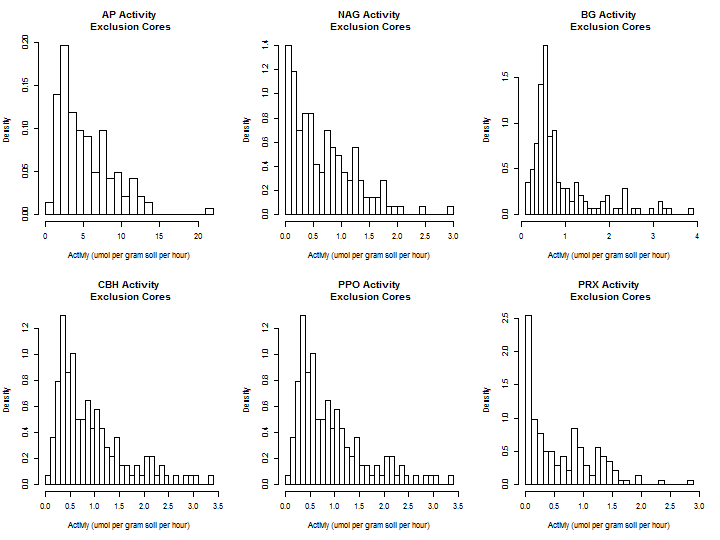

```r
par(mfrow=c(2,3))

hist(WCS_enzyme.data$acid_phosphatase[which(WCS_enzyme.data$Core_Type=="50um Exclusion")],
     breaks=30, freq=FALSE,
     main = "AP Activity\n Exclusion Cores",
     xlab = "Activiy (umol per gram soil per hour)",
     ylab = "Density")

hist(WCS_enzyme.data$NAG[which(WCS_enzyme.data$Core_Type=="50um Exclusion")],
     breaks=30, freq=FALSE,
     main = "NAG Activity\n Exclusion Cores",
     xlab = "Activiy (umol per gram soil per hour)",
     ylab = "Density")

hist(WCS_enzyme.data$beta_glucosidase[which(WCS_enzyme.data$Core_Type=="50um Exclusion")],
     breaks=30, freq=FALSE,
     main = "BG Activity\n Exclusion Cores",
     xlab = "Activiy (umol per gram soil per hour)",
     ylab = "Density")

hist(WCS_enzyme.data$phenol_oxidase[which(WCS_enzyme.data$Core_Type=="50um Exclusion")],
     breaks=30, freq=FALSE,
     main = "CBH Activity\n Exclusion Cores",
     xlab = "Activiy (umol per gram soil per hour)",
     ylab = "Density")

hist(WCS_enzyme.data$phenol_oxidase[which(WCS_enzyme.data$Core_Type=="50um Exclusion")],
     breaks=30, freq=FALSE,
     main = "PPO Activity\n Exclusion Cores",
     xlab = "Activiy (umol per gram soil per hour)",
     ylab = "Density")

hist(WCS_enzyme.data$peroxidase[which(WCS_enzyme.data$Core_Type=="50um Exclusion")],
     breaks=30, freq=FALSE,
     main = "PRX Activity\n Exclusion Cores",
     xlab = "Activiy (umol per gram soil per hour)",
     ylab = "Density")
```

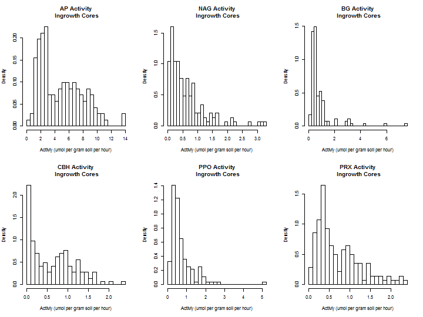

```r
par(mfrow=c(2,3))

hist(WCS_enzyme.data$acid_phosphatase[which(WCS_enzyme.data$Core_Type=="Ingrowth")],
     breaks=30, freq=FALSE,
     main = "AP Activity\n Ingrowth Cores",
     xlab = "Activiy (umol per gram soil per hour)",
     ylab = "Density")

hist(WCS_enzyme.data$NAG[which(WCS_enzyme.data$Core_Type=="Ingrowth")],
     breaks=30, freq=FALSE,
     main = "NAG Activity\n Ingrowth Cores",
     xlab = "Activiy (umol per gram soil per hour)",
     ylab = "Density")

hist(WCS_enzyme.data$beta_glucosidase[which(WCS_enzyme.data$Core_Type=="Ingrowth")],
     breaks=30, freq=FALSE,
     main = "BG Activity\n Ingrowth Cores",
     xlab = "Activiy (umol per gram soil per hour)",
     ylab = "Density")

hist(WCS_enzyme.data$cellobiohydrolase[which(WCS_enzyme.data$Core_Type=="Ingrowth")],
     breaks=30, freq=FALSE,
     main = "CBH Activity\n Ingrowth Cores",
     xlab = "Activiy (umol per gram soil per hour)",
     ylab = "Density")

hist(WCS_enzyme.data$phenol_oxidase[which(WCS_enzyme.data$Core_Type=="Ingrowth")],
     breaks=30, freq=FALSE,
     main = "PPO Activity\n Ingrowth Cores",
     xlab = "Activiy (umol per gram soil per hour)",
     ylab = "Density")

hist(WCS_enzyme.data$peroxidase[which(WCS_enzyme.data$Core_Type=="Ingrowth")],
     breaks=30, freq=FALSE,
     main = "PRX Activity\n Ingrowth Cores",
     xlab = "Activiy (umol per gram soil per hour)",
     ylab = "Density")
```

Anyway, that's how far I am on this project. I am a little stuck on how to analyze things in the glmm framework, especially how to specify error distributions for the root data and Nmin - suggestions and feedback is greatly appreciated ~ Pat